# Gmisc

[figure not shown]

**Gmisc** collects utilities for the graphics and tables that recur in medical research papers — built so they compose with the native R pipe (`|>`):

- **Descriptive “Table 1”** — `getDescriptionStatsBy()` + `htmlTable()` for publication-ready, copy-paste descriptive tables.
- **Grid-based flowcharts** — a `flowchart() |> spread() |> move() |> connect()` pipeline for CONSORT-style diagrams, including `phaseLabel()` headings.
- **Transition plots** — the `Transition` class for visualising how observations move between categories over time.
- **SVD variable selection** — `getSvdMostInfluential()` for picking influential variables.
- **Bézier arrows** — smooth arrows complementing the `grid` package.

## Installation

```r
# From CRAN
install.packages("Gmisc")

# Development version from GitHub
# install.packages("remotes")
remotes::install_github("gforge/Gmisc")
```

## Flowcharts & CONSORT diagrams

Build a flowchart as a named list of boxes, position the columns with `spread()`/`move()`, then add the connectors. Parallel arms are just lists, and `phaseLabel()` drops a CONSORT phase heading (“Allocation”, “Follow-up”, …) between the arms — centred, slightly overlapping, and drawn on top.

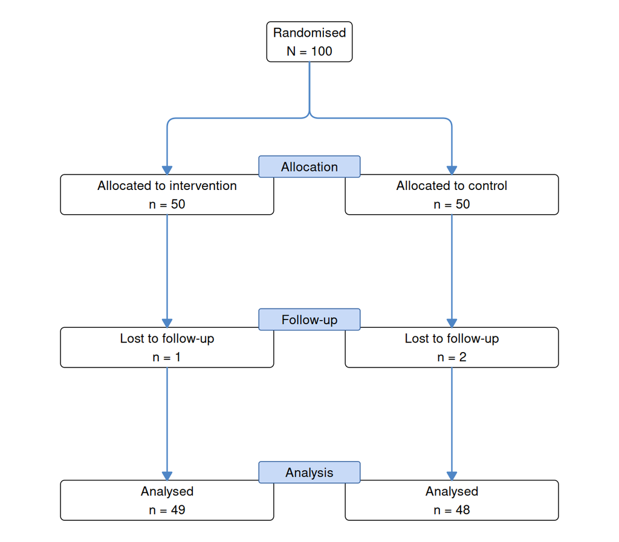

```r
library(Gmisc)
library(grid)

main_gp <- gpar(fill = "white", col = "black", lwd = 1)
head_gp <- gpar(fill = "#c8daf7", col = "#2f5f9f", lwd = 1)
con_gp  <- gpar(col = "#4f86c6", fill = "#4f86c6", lwd = 1.8)
sw      <- unit(70, "mm")

flowchart(
  rando = boxGrob("Randomised\nN = 100", box_gp = main_gp),
  groups = list(
    boxGrob("Allocated to intervention\nn = 50", width = sw, box_gp = main_gp),
    boxGrob("Allocated to control\nn = 50", width = sw, box_gp = main_gp)
  ),
  followup = list(
    boxGrob("Lost to follow-up\nn = 1", width = sw, box_gp = main_gp),
    boxGrob("Lost to follow-up\nn = 2", width = sw, box_gp = main_gp)
  ),
  analysis = list(
    boxGrob("Analysed\nn = 49", width = sw, box_gp = main_gp),
    boxGrob("Analysed\nn = 48", width = sw, box_gp = main_gp)
  )
) |>
  spread(axis = "y", margin = unit(0.04, "npc")) |>
  move(subelement = list(c("groups", 1), c("followup", 1), c("analysis", 1)), x = 0.27) |>
  move(subelement = list(c("groups", 2), c("followup", 2), c("analysis", 2)), x = 0.73) |>
  phaseLabel("groups",   "Allocation", box_gp = head_gp) |>
  phaseLabel("followup", "Follow-up",  box_gp = head_gp) |>
  phaseLabel("analysis", "Analysis",   box_gp = head_gp) |>
  connect("rando",    "groups",   type = "N", lty_gp = con_gp, arrow_size = 3, smooth = TRUE) |>
  connect("groups",   "followup", type = "v", lty_gp = con_gp, arrow_size = 3) |>
  connect("followup", "analysis", type = "v", lty_gp = con_gp, arrow_size = 3)
```

See `vignette("Grid-based_flowcharts", package = "Gmisc")` for the full API.

## Descriptive “Table 1”

`getDescriptionStatsBy()` summarises variables split by a grouping column. It is often used with `mergeDesc()` to group related variables into sections, and pipes straight into `htmlTable()` for a publication-ready table.

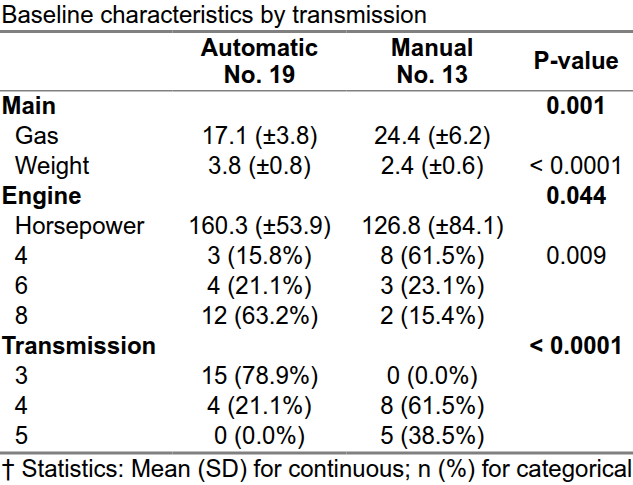

```r
library(dplyr)
library(Gmisc)

# A custom wrapper to keep statistics and formatting consistent
# (e.g., same digits, p-values, and header count)
get_stats <- function(data, ...) {
  res <- data |>
    getDescriptionStatsBy(...,
                          by = am,
                          statistics = TRUE,
                          digits = 1,
                          header_count = TRUE)
  if (is.list(res)) {
    return(do.call(rbind, res))
  }
  return(res)
}

mtcars_prep <- mtcars |>
  mutate(am = factor(am, labels = c("Automatic", "Manual")),
         gear = factor(gear),
         cyl = factor(cyl)) |>
  set_column_labels(mpg = "Gas",
                    wt = "Weight",
                    hp = "Horsepower",
                    cyl = "Cylinders",
                    gear = "Gears") |>
  set_column_units(mpg = "Miles/gallon",
                   wt = "10<sup>3</sup> lbs",
                   hp = "hp")

# Group variables and merge them into a single table
mergeDesc(
  "Main" = mtcars_prep |> get_stats(mpg, wt),
  "Engine" = mtcars_prep |> get_stats(hp, cyl),
  "Transmission" = mtcars_prep |> get_stats(gear)
) |>
  htmlTable(caption = "Baseline characteristics by transmission",
            tfoot = "&dagger; Statistics: Mean (SD) for continuous; n (%) for categorical")
```

See `vignette("Descriptives", package = "Gmisc")` for the many formatting options.

## Transition plots

The `Transition` class shows how observations move between classes over time; a third dimension can be encoded as a colour split within each box.

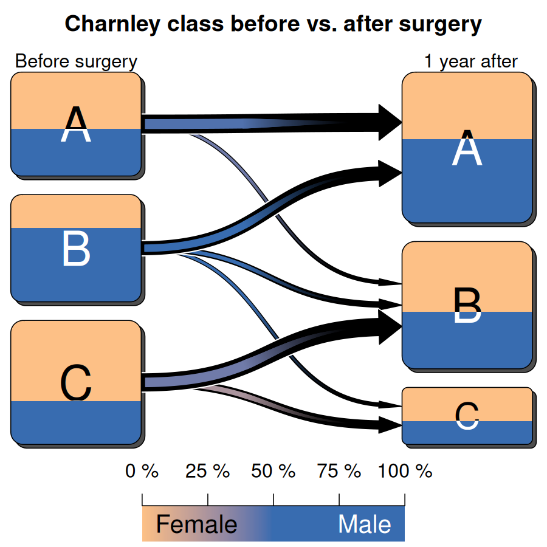

```r
set.seed(1)
n <- 100
sex    <- sample(c("Male", "Female"), n, replace = TRUE)
before <- sample(1:3, n, replace = TRUE)
# Most cases improve one class, some stay, a few worsen
after  <- pmin(pmax(before - sample(c(-1, 0, 1), n, replace = TRUE, prob = c(.15, .35, .5)), 1), 3)

lbl <- c("A", "B", "C")
tbl <- table(factor(before, 1:3, lbl), factor(after, 1:3, lbl), sex)

transitions <- getRefClass("Transition")$new(tbl, label = c("Before surgery", "1 year after"))
transitions$title   <- "Charnley class before vs. after surgery"
transitions$clr_bar <- "bottom"
transitions$render()
```

See `vignette("Transition-class", package = "Gmisc")` for customisation.

## Learn more

- Project page: https://gforge.se
- Vignettes: `browseVignettes("Gmisc")`
- Bugs & feature requests: https://github.com/gforge/Gmisc/issues